# Regressão Logistica (Titanic) - aula

Ana Cristina Braga

2024-11-26

```r
if(!require(dplyr)){install.packages("dplyr")}
if(!require(tidyr)){install.packages("tidyr")}
```

```r
if(!require(ggplot2)){install.packages("ggplot2")}
if(!require(broom)){install.packages("broom")}
if(!require(Amelia)){install.packages("Amelia")}
```

[output not shown]

```r
if(!require(caret)){install.packages("caret")}
if(!require(pscl)){install.packages("pscl")}
```

[output not shown]

```r
if(!require(pROC)){install.packages("pROC")}
if(!require(ROCR)){install.packages("ROCR")}
if(!require(tidyverse)){install.packages("tidyverse")}
```

## Sobre as variáveis no ficheiro:

Pclass: Passenger Class (1 = 1st; 2 = 2nd; 3 = 3rd)

Survived: Survival (0 = No; 1 = Yes)

Name: Name

Sex: Sex

Age: Age

SibSp: Number of Siblings/Spouses Aboard

Parch: Number of Parents/Children Aboard

Ticket: Ticket Number

Fare: Passenger Fare (British pound)

Cabin: Cabin

Embarked: Port of Embarkation (C = Cherbourg; Q = Queenstown; S = Southampton)

## Tratamento dos dados

```r
training.data.raw <- read.csv('train_Titanic.csv',header=T,na.strings=c(""))
#View(training.data.raw)
```

Agora precisamos verificar os valores omissos e verificar quantos valores exclusivos existem para cada variável usando a função *sapply()* que aplica a função passada como argumento a cada coluna do dataframe.

```r
sapply(training.data.raw,function(x) sum(is.na(x)))
```

```
## PassengerId    Survived      Pclass        Name         Sex         Age
##           0           0           0           0           0         177
##       SibSp       Parch      Ticket        Fare       Cabin    Embarked
##           0           0           0           0         687           2
```

```r
sapply(training.data.raw, function(x) length(unique(x)))
```

```
## PassengerId    Survived      Pclass        Name         Sex         Age
##         891           2           3         891           2          89
##       SibSp       Parch      Ticket        Fare       Cabin    Embarked
##           7           7         681         248         148           4
```

Um exame visual dos valores omissos pode ser útil: o pacote Amelia possui uma função gráfica especial, missmap(), que irá representar o conjunto de dados e destacar os valores em falta:

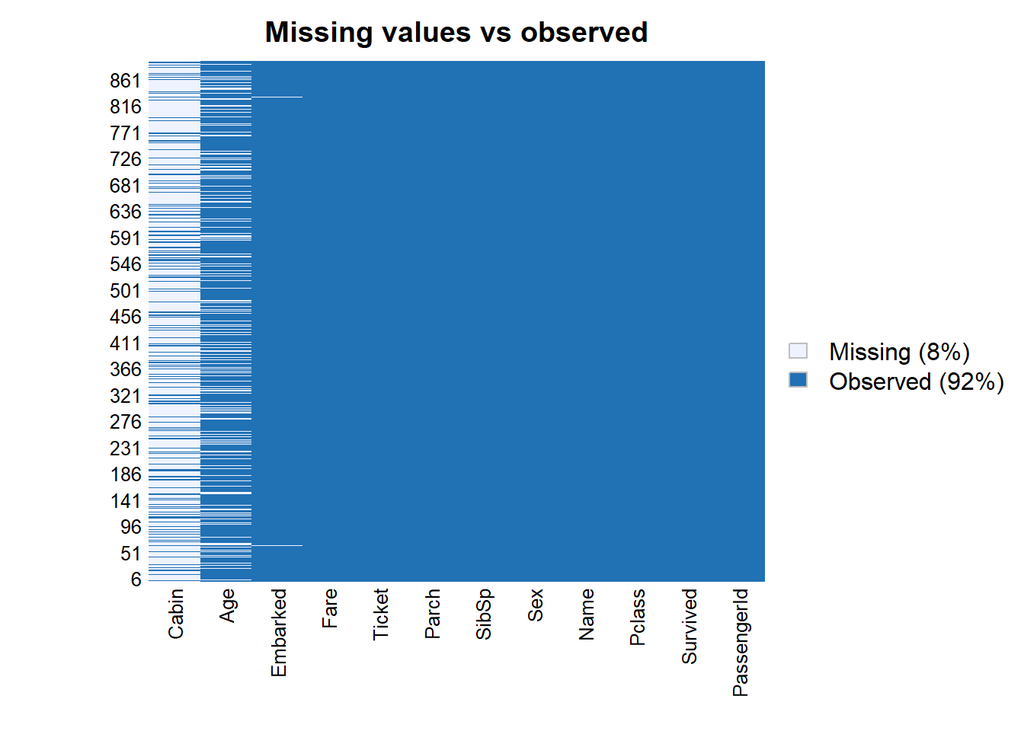

A variável “Cabin” tem muitos valores omissos, optámos por a eliminar. Também eliminaremos “PassengerId”“, pois é apenas um indicador. Usando a função subset(), criamos um subconjunto de dados, selecionando apenas as colunas relevantes.

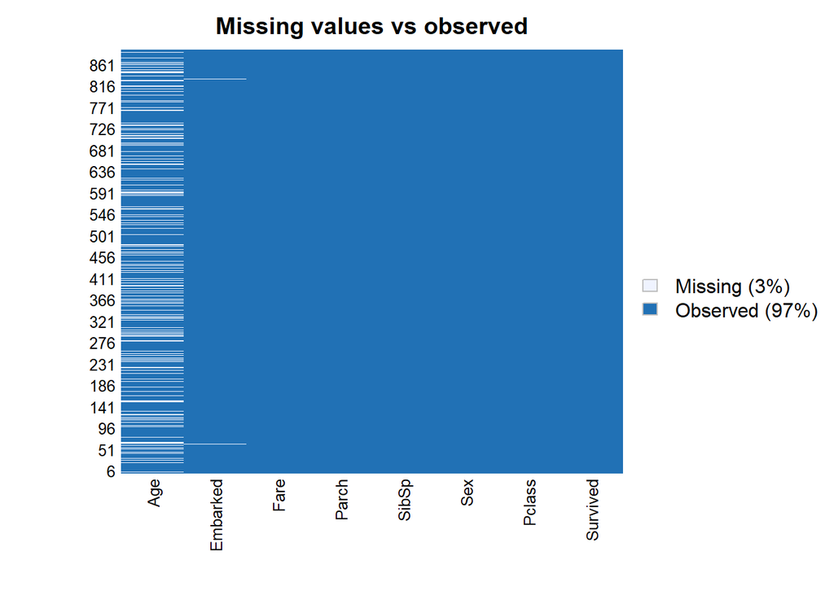

```r
data<- subset(training.data.raw,select=c(2,3,5,6,7,8,10,12))
missmap(data, main = "Missing values vs observed")
```

## Tratamento dos valores ausentes

Agora precisamos considerar os restantes valores omissos. O R pode lidar facilmente com eles quando ajusta um modelo linear generalizado, definindo um parâmetro dentro da função de ajuste. No entanto, pessoalmente, prefiro substituir os NAs “à mão” quando for possível. Existem diferentes maneiras de fazer isso, uma abordagem típica é substituir os valores ausentes pela média, mediana ou moda do existente. Neste exemplo utilizaremos a média.

```r
data$Age[is.na(data$Age)] <- mean(data$Age,na.rm=T)
```

No que diz respeito às variáveis categóricas, o uso de *read.table()* ou *read.csv()*, por norma, codificará as variáveis categóricas como fatores. Um fator é como o R lida com variáveis categóricas. Podemos verificar a codificação usando as seguintes linhas de código:

```r
data$Sex<-factor(data$Sex) # declara como categorica a variável sexo
is.factor(data$Sex)
```

```
## [1] TRUE
```

```r
summary(data$Sex)
```

```
## female   male
##    314    577
```

```r
data$Embarked<-factor(data$Embarked) #declara como categorica a variável Embarked
is.factor(data$Embarked)
```

```
## [1] TRUE
```

```r
data$Pclass<-factor(data$Pclass) #declara como categorica a variável PClass
is.factor(data$Pclass)
```

```
## [1] TRUE
```

Para uma melhor compreensão de como R vai lidar com as variáveis categóricas, podemos usar a função contrasts(). Esta função nos mostrará como as variáveis foram codificadas pelo R e como interpretá-las em um modelo.

```r
contrasts(data$Sex)
```

```
##        male
## female    0
## male      1
```

```r
contrasts(data$Embarked)
```

```
##   Q S
## C 0 0
## Q 1 0
## S 0 1
```

```r
contrasts(data$Pclass)
```

```
##   2 3
## 1 0 0
## 2 1 0
## 3 0 1
```

Por exemplo, verifica-se que na variável género, o sexo feminino será usado como referência. Quanto aos valores omissos na variável “Embarked”, já que existem apenas dois, vamos eliminar essas duas linhas (poderíamos também ter substituído os valores perdidos pela moda e manter os pontos de dados).

```r
data1 <- data[!is.na(data$Embarked),]
rownames(data1) <- NULL #retira os labels às linhas
```

Antes de prosseguir para o processo de ajuste de modelo, é importante salientar a importância da “limpeza” e formatação dos dados. Esta etapa de pré-processamento é frequentemente crucial para obter um bom ajuste do modelo e melhor capacidade de previsão.

## Modelação

Nós dividimos os dados em dois blocos: treino e teste. O conjunto de treino será usado para ajustar o modelo, que será testado no conjunto de teste.

```r
library(caret)

# Prep Training and Test data.
set.seed(100)
trainDataIndex <- createDataPartition(data1$Survived, p=0.7, list = F) # 70% training data
train <- data1[trainDataIndex, ]
test <- data1[-trainDataIndex, ]

#Modelo
model <- glm(Survived ~.,family=binomial(link='logit'),data=train)
summary(model)
```

```
##
## Call:
## glm(formula = Survived ~ ., family = binomial(link = "logit"),
##     data = train)
##
## Coefficients:
##              Estimate Std. Error z value Pr(>|z|)
## (Intercept)  3.728200   0.551424   6.761 1.37e-11 ***
## Pclass2     -0.704678   0.350719  -2.009   0.0445 *
## Pclass3     -2.147765   0.355175  -6.047 1.48e-09 ***
## Sexmale     -2.610151   0.235514 -11.083  < 2e-16 ***
## Age         -0.036067   0.009038  -3.991 6.59e-05 ***
## SibSp       -0.253952   0.126160  -2.013   0.0441 *
## Parch       -0.004344   0.140142  -0.031   0.9753
## Fare         0.001989   0.002862   0.695   0.4870
## EmbarkedQ    0.493465   0.465339   1.060   0.2889
## EmbarkedS   -0.386450   0.289148  -1.337   0.1814
## ---
## Signif. codes:  0 '***' 0.001 '**' 0.01 '*' 0.05 '.' 0.1 ' ' 1
##
## (Dispersion parameter for binomial family taken to be 1)
##
##     Null deviance: 832.39  on 622  degrees of freedom
## Residual deviance: 551.50  on 613  degrees of freedom
## AIC: 571.5
##
## Number of Fisher Scoring iterations: 5
```

```r
yhat=fitted.values(model)
```

## Interpretando os resultados do modelo de regressão logística

Agora podemos analisar o modelo e interpretar o significado deste. Assim, verifica-se que o “Parch”, “Fare” e “Embarked” não são estatisticamente significativos. Quanto às variáveis estatisticamente significativas, o sexo apresenta um valor de p <0.05, sugerindo uma associação do sexo do passageiro com a probabilidade de ter sobrevivido. O coeficiente negativo para este preditor sugere que todas as outras variáveis sendo iguais, o passageiro do sexo masculino é menos provável que tenha sobrevivido. Lembre-se que no modelo logit a variável resposta é log odds: $\ln (odds) = \ln \left( \frac{p}{1-p} \right) = b_0+b_1*x_1+b_2*x_2 +\cdots+ b_k*x_k$. Como o masculino é uma variável , ser do sexo masculino reduz as probabilidades do log em 2,61, enquanto o aumento de uma unidade na idade reduz as chances do log em 0,036.

Agora podemos executar a função anova() no modelo para analisar a tabela da deviance.

```r
anova(model, test="Chisq")
```

```
## Analysis of Deviance Table
##
## Model: binomial, link: logit
##
## Response: Survived
##
## Terms added sequentially (first to last)
##
##
##          Df Deviance Resid. Df Resid. Dev  Pr(>Chi)
## NULL                       622     832.39
## Pclass    2   70.416       620     761.97 5.122e-16 ***
## Sex       1  183.607       619     578.36 < 2.2e-16 ***
## Age       1   13.937       618     564.43  0.000189 ***
## SibSp     1    6.102       617     558.32  0.013506 *
## Parch     1    0.027       616     558.30  0.870093
## Fare      1    0.977       615     557.32  0.323040
## Embarked  2    5.818       613     551.50  0.054534 .
## ---
## Signif. codes:  0 '***' 0.001 '**' 0.01 '*' 0.05 '.' 0.1 ' ' 1
```

A diferença entre o desvio nulo (null deviance) e o desvio residual (deviance) mostra como o modelo está em relação ao modelo nulo (um modelo com apenas a constante). Quanto maior esta lacuna, melhor. Analisando a tabela, podemos ver o decréscimo no desvio ao adicionar cada variável, uma de cada vez. Novamente, adicionar “Pclass”, “Sex” e “Age” reduz significativamente o desvio residual. As outras variáveis parecem melhorar menos o modelo, mesmo que o “SibSp” tenha um baixo valor de p. Um grande valor-p aqui indica que o modelo sem a variável explica mais ou menos a mesma quantidade de variação. Em última análise, o que se gostaria de ver era uma queda significativa no desvio e na AIC.

Embora não exista um equivalente ao $R^2$ de regressão linear, o índice $R^2$ de McFadden pode ser usado para avaliar o ajuste do modelo.

```r
library(pscl)
pR2(model)
```

```
## fitting null model for pseudo-r2
```

```
##          llh      llhNull           G2     McFadden         r2ML         r2CU
## -275.7515371 -416.1929896  280.8829049    0.3374431    0.3629170    0.4923384
```

## Modelo reduzido

```r
model2=glm(Survived ~Pclass+Sex+Age+SibSp,family=binomial(link='logit'),data=train)
summary(model2)
```

```
##
## Call:
## glm(formula = Survived ~ Pclass + Sex + Age + SibSp, family = binomial(link = "logit"),
##     data = train)
##
## Coefficients:
##              Estimate Std. Error z value Pr(>|z|)
## (Intercept)  3.704932   0.455060   8.142 3.90e-16 ***
## Pclass2     -0.913422   0.308400  -2.962  0.00306 **
## Pclass3     -2.220219   0.284213  -7.812 5.64e-15 ***
## Sexmale     -2.691807   0.230116 -11.698  < 2e-16 ***
## Age         -0.036267   0.008983  -4.037 5.41e-05 ***
## SibSp       -0.278487   0.119202  -2.336  0.01948 *
## ---
## Signif. codes:  0 '***' 0.001 '**' 0.01 '*' 0.05 '.' 0.1 ' ' 1
##
## (Dispersion parameter for binomial family taken to be 1)
##
##     Null deviance: 832.39  on 622  degrees of freedom
## Residual deviance: 558.32  on 617  degrees of freedom
## AIC: 570.32
##
## Number of Fisher Scoring iterations: 5
```

```r
if(!require(MASS)){install.packages("MASS")}
library("MASS")

step.model <- stepAIC(model, direction = "both",
                      trace = FALSE)
summary(step.model)
```

```
##
## Call:
## glm(formula = Survived ~ Pclass + Sex + Age + SibSp + Embarked,
##     family = binomial(link = "logit"), data = train)
##
## Coefficients:
##              Estimate Std. Error z value Pr(>|z|)
## (Intercept)  3.919980   0.484091   8.098 5.60e-16 ***
## Pclass2     -0.808982   0.318261  -2.542   0.0110 *
## Pclass3     -2.280266   0.301181  -7.571 3.70e-14 ***
## Sexmale     -2.623157   0.231218 -11.345  < 2e-16 ***
## Age         -0.036590   0.009005  -4.063 4.84e-05 ***
## SibSp       -0.237163   0.118804  -1.996   0.0459 *
## EmbarkedQ    0.467979   0.460995   1.015   0.3100
## EmbarkedS   -0.418168   0.285054  -1.467   0.1424
## ---
## Signif. codes:  0 '***' 0.001 '**' 0.01 '*' 0.05 '.' 0.1 ' ' 1
##
## (Dispersion parameter for binomial family taken to be 1)
##
##     Null deviance: 832.39  on 622  degrees of freedom
## Residual deviance: 552.03  on 615  degrees of freedom
## AIC: 568.03
##
## Number of Fisher Scoring iterations: 5
```

```r
step.modelb <- stepAIC(model, direction = "backward",
                      trace = FALSE)
summary(step.modelb)
```

```
##
## Call:
## glm(formula = Survived ~ Pclass + Sex + Age + SibSp + Embarked,
##     family = binomial(link = "logit"), data = train)
##
## Coefficients:
##              Estimate Std. Error z value Pr(>|z|)
## (Intercept)  3.919980   0.484091   8.098 5.60e-16 ***
## Pclass2     -0.808982   0.318261  -2.542   0.0110 *
## Pclass3     -2.280266   0.301181  -7.571 3.70e-14 ***
## Sexmale     -2.623157   0.231218 -11.345  < 2e-16 ***
## Age         -0.036590   0.009005  -4.063 4.84e-05 ***
## SibSp       -0.237163   0.118804  -1.996   0.0459 *
## EmbarkedQ    0.467979   0.460995   1.015   0.3100
## EmbarkedS   -0.418168   0.285054  -1.467   0.1424
## ---
## Signif. codes:  0 '***' 0.001 '**' 0.01 '*' 0.05 '.' 0.1 ' ' 1
##
## (Dispersion parameter for binomial family taken to be 1)
##
##     Null deviance: 832.39  on 622  degrees of freedom
## Residual deviance: 552.03  on 615  degrees of freedom
## AIC: 568.03
##
## Number of Fisher Scoring iterations: 5
```

```r
step.modelf <- stepAIC(model, direction = "forward",
                       trace = FALSE)
summary(step.modelf)
```

```
##
## Call:
## glm(formula = Survived ~ Pclass + Sex + Age + SibSp + Parch +
##     Fare + Embarked, family = binomial(link = "logit"), data = train)
##
## Coefficients:
##              Estimate Std. Error z value Pr(>|z|)
## (Intercept)  3.728200   0.551424   6.761 1.37e-11 ***
## Pclass2     -0.704678   0.350719  -2.009   0.0445 *
## Pclass3     -2.147765   0.355175  -6.047 1.48e-09 ***
## Sexmale     -2.610151   0.235514 -11.083  < 2e-16 ***
## Age         -0.036067   0.009038  -3.991 6.59e-05 ***
## SibSp       -0.253952   0.126160  -2.013   0.0441 *
## Parch       -0.004344   0.140142  -0.031   0.9753
## Fare         0.001989   0.002862   0.695   0.4870
## EmbarkedQ    0.493465   0.465339   1.060   0.2889
## EmbarkedS   -0.386450   0.289148  -1.337   0.1814
## ---
## Signif. codes:  0 '***' 0.001 '**' 0.01 '*' 0.05 '.' 0.1 ' ' 1
##
## (Dispersion parameter for binomial family taken to be 1)
##
##     Null deviance: 832.39  on 622  degrees of freedom
## Residual deviance: 551.50  on 613  degrees of freedom
## AIC: 571.5
##
## Number of Fisher Scoring iterations: 5
```

## Avaliando a capacidade preditiva do modelo e modelo reduzido

Nas etapas acima, avaliamos o ajuste do modelo, agora gostaríamos de ver como o modelo se comporta para predizer $y$ num novo conjunto de dados. Definindo o parâmetro type = ‘response’, o R irá gerar probabilidades na forma de P (y = 1 | X). Nosso limite de decisão será 0,5. Se P (y = 1 | X)> 0,5, então y = 1, caso contrário, y = 0. Note que, para algumas aplicações, diferentes limites de decisão podem ser uma opção melhor.

```r
fitted.results <- predict(model,newdata=subset(test,select=c(2,3,4,5,6,7,8)),type='response')
fitted.results <- ifelse(fitted.results > 0.5,1,0)
misClasificError <- mean(fitted.results != test$Survived)
print(paste('Accuracy',1-misClasificError))
```

```
## [1] "Accuracy 0.815789473684211"
```

```r
fitted.results2 <- predict(model2,newdata=subset(test,select=c(2,3,4,5,6,7,8)),type='response')
fitted.results2 <- ifelse(fitted.results2 > 0.5,1,0)
misClasificError2 <- mean(fitted.results2 != test$Survived)
print(paste('Accuracy2',1-misClasificError2))
```

```
## [1] "Accuracy2 0.808270676691729"
```

A precisão de 0,816 no conjunto de testes é um bom resultado. No entanto, deve-se ter em conta que esse resultado é um pouco dependente da divisão manual dos dados que fizemos anteriormente, portanto, se desejarmos um valor mais preciso, seria melhor executar algum tipo de validação cruzada, como k-fold cross validation.

Como último passo, vamos desenhar a curva ROC e calcular a AUC (área abaixo da curva) que são medidas típicas de desempenho para um classificador binário. A ROC é uma curva gerada pela representação gráfica da Fração de verdadeiros positivos (FVP ou TPF) contra a fração de falsos positivos (FFP ou FPF) em várias valores de corte, enquanto a AUC é a área abaixo da curva ROC. Como regra geral, um modelo com boa capacidade de previsão deve ter uma AUC próxima a 1 (1 é ideal) do que a 0,5.

```r
library(ROCR)
p <- predict(model, newdata=subset(test,select=c(2,3,4,5,6,7,8)), type="response")
pr <- prediction(p, test$Survived)
prf <- performance(pr, measure = "tpr", x.measure = "fpr")
plot(prf)

auc <- performance(pr, measure = "auc")
auc <- auc@y.values[[1]]
auc
```

```
## [1] 0.8517979
```

```r
#validação interna

pr_i <- prediction(yhat, train$Survived)
prf_i <- performance(pr_i, measure = "tpr", x.measure = "fpr")

auc_i <- performance(pr_i, measure = "auc")
auc_i <- auc_i@y.values[[1]]
auc_i
```

```
## [1] 0.8557461
```

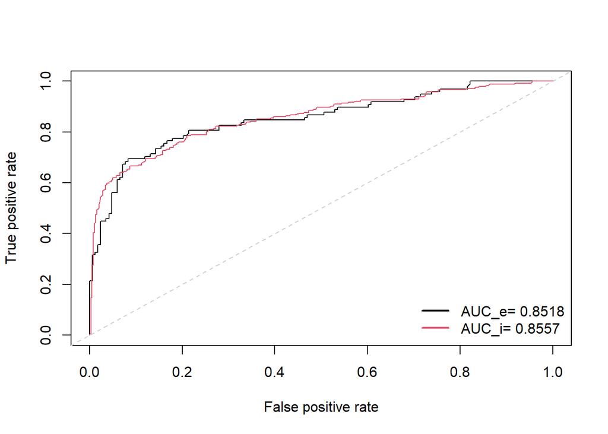

```
## [1] "AUC_e= 0.8518"
## [1] "AUC_i= 0.8557"
```

```r
plot(prf_i, col=2, add=T)
abline(c(0,1), lty=2, col="lightgrey")

legend("bottomright",c(print(paste('AUC_e=',round(auc,digits=4))),print(paste('AUC_i=',round(auc_i,digits=4)))),col=c(1,2),lwd=2,bty="n")
```

## Curva ROC para o modelo 2

```r
p2 <- predict(model2, newdata=subset(test,select=c(2,3,4,5,6,7,8)), type="response")
pr2 <- prediction(p2, test$Survived)
prf2 <- performance(pr2, measure = "tpr", x.measure = "fpr")
plot(prf2)

auc2 <- performance(pr2, measure = "auc")
auc2 <- auc2@y.values[[1]]
auc2
```

```
## [1] 0.8596939
```

```r
#validação interna
yhat2<-fitted.values(model2)
pr_i2 <- prediction(yhat2, train$Survived)
prf_i2 <- performance(pr_i2, measure = "tpr", x.measure = "fpr")

auc_i2 <- performance(pr_i2, measure = "auc")
auc_i2 <- auc_i2@y.values[[1]]
auc_i2
```

```
## [1] 0.8501822
```

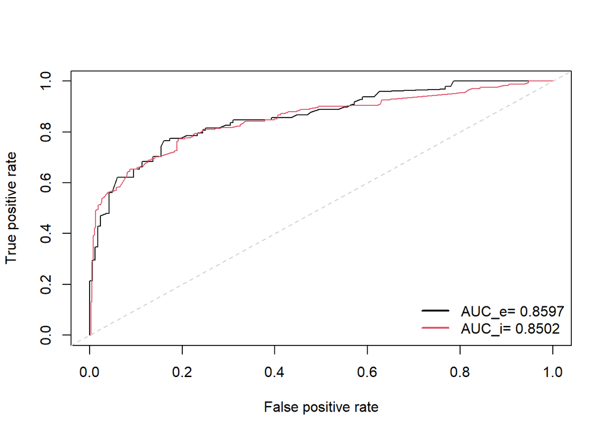

```
## [1] "AUC_e= 0.8597"
## [1] "AUC_i= 0.8502"
```

```r
plot(prf_i2, col=2, add=T)
abline(c(0,1), lty=2, col="lightgrey")

legend("bottomright",c(print(paste('AUC_e=',round(auc2,digits=4))),print(paste('AUC_i=',round(auc_i2,digits=4)))),col=c(1,2),lwd=2,bty="n")
```